# Predicting Housing Prices

Kyle Brewster

2022-05-30

# 01 - Briefly explain why being able to predict whether my model underpredicted a house’s price means that your model “beats” my model.

If I am able to predict if the model is under-predicting, then that means I would grouped the data in very similar groups as the model that predicted `undervalued`. Along the way, I will also gather an idea of how confident the models’ prediction of `undervalued` is. With this information, by the end of my modeling I will have (in theory) predicted whether an observation is `undervalued` by its defined characteristics, but also would have an idea of “how much” and “in which direction” the difference between the actual and suggested validation of an observation (i.e. 3>1)

# 02 - Use two different models to predict undervalued

```r
housing = read.csv("final-data.csv")
```

Since we are attempting to predict a T/F value, we will be using methods of classification.

To get an overview of the data

```r
# For handy viewing from environment
skimr::skim(housing) -> skim_df
skimr::skim(housing)
```

Data summary

| Name | housing |
| --- | --- |
| Number of rows | 1460 |
| Number of columns | 81 |
| _______________________ |  |
| Column type frequency: |  |
| character | 43 |
| logical | 1 |
| numeric | 37 |
| ________________________ |  |
| Group variables | None |

**Variable type: character**

| skim_variable | n_missing | complete_rate | min | max | empty | n_unique | whitespace |
| --- | --- | --- | --- | --- | --- | --- | --- |
| ms_zoning | 0 | 1.00 | 2 | 7 | 0 | 5 | 0 |
| street | 0 | 1.00 | 4 | 4 | 0 | 2 | 0 |
| alley | 1369 | 0.06 | 4 | 4 | 0 | 2 | 0 |
| lot_shape | 0 | 1.00 | 3 | 3 | 0 | 4 | 0 |
| land_contour | 0 | 1.00 | 3 | 3 | 0 | 4 | 0 |
| utilities | 0 | 1.00 | 6 | 6 | 0 | 2 | 0 |
| lot_config | 0 | 1.00 | 3 | 7 | 0 | 5 | 0 |
| land_slope | 0 | 1.00 | 3 | 3 | 0 | 3 | 0 |
| neighborhood | 0 | 1.00 | 5 | 7 | 0 | 25 | 0 |
| condition1 | 0 | 1.00 | 4 | 6 | 0 | 9 | 0 |
| condition2 | 0 | 1.00 | 4 | 6 | 0 | 8 | 0 |
| bldg_type | 0 | 1.00 | 4 | 6 | 0 | 5 | 0 |
| house_style | 0 | 1.00 | 4 | 6 | 0 | 8 | 0 |
| roof_style | 0 | 1.00 | 3 | 7 | 0 | 6 | 0 |
| roof_matl | 0 | 1.00 | 4 | 7 | 0 | 8 | 0 |
| exterior1st | 0 | 1.00 | 5 | 7 | 0 | 15 | 0 |
| exterior2nd | 0 | 1.00 | 5 | 7 | 0 | 16 | 0 |
| mas_vnr_type | 8 | 0.99 | 4 | 7 | 0 | 4 | 0 |
| exter_qual | 0 | 1.00 | 2 | 2 | 0 | 4 | 0 |
| exter_cond | 0 | 1.00 | 2 | 2 | 0 | 5 | 0 |
| foundation | 0 | 1.00 | 4 | 6 | 0 | 6 | 0 |
| bsmt_qual | 37 | 0.97 | 2 | 2 | 0 | 4 | 0 |
| bsmt_cond | 37 | 0.97 | 2 | 2 | 0 | 4 | 0 |
| bsmt_exposure | 38 | 0.97 | 2 | 2 | 0 | 4 | 0 |
| bsmt_fin_type1 | 37 | 0.97 | 3 | 3 | 0 | 6 | 0 |
| bsmt_fin_type2 | 38 | 0.97 | 3 | 3 | 0 | 6 | 0 |
| heating | 0 | 1.00 | 4 | 5 | 0 | 6 | 0 |
| heating_qc | 0 | 1.00 | 2 | 2 | 0 | 5 | 0 |
| central_air | 0 | 1.00 | 1 | 1 | 0 | 2 | 0 |
| electrical | 1 | 1.00 | 3 | 5 | 0 | 5 | 0 |
| kitchen_qual | 0 | 1.00 | 2 | 2 | 0 | 4 | 0 |
| functional | 0 | 1.00 | 3 | 4 | 0 | 7 | 0 |
| fireplace_qu | 690 | 0.53 | 2 | 2 | 0 | 5 | 0 |
| garage_type | 81 | 0.94 | 6 | 7 | 0 | 6 | 0 |
| garage_finish | 81 | 0.94 | 3 | 3 | 0 | 3 | 0 |
| garage_qual | 81 | 0.94 | 2 | 2 | 0 | 5 | 0 |
| garage_cond | 81 | 0.94 | 2 | 2 | 0 | 5 | 0 |
| paved_drive | 0 | 1.00 | 1 | 1 | 0 | 3 | 0 |
| pool_qc | 1453 | 0.00 | 2 | 2 | 0 | 3 | 0 |
| fence | 1179 | 0.19 | 4 | 5 | 0 | 4 | 0 |
| misc_feature | 1406 | 0.04 | 4 | 4 | 0 | 4 | 0 |
| sale_type | 0 | 1.00 | 2 | 5 | 0 | 9 | 0 |
| sale_condition | 0 | 1.00 | 6 | 7 | 0 | 6 | 0 |

**Variable type: logical**

| skim_variable | n_missing | complete_rate | mean | count |
| --- | --- | --- | --- | --- |
| undervalued | 0 | 1 | 0.48 | FAL: 754, TRU: 706 |

**Variable type: numeric**

| skim_variable | n_missing | complete_rate | mean | sd | p0 | p25 | p50 | p75 | p100 | hist |
| --- | --- | --- | --- | --- | --- | --- | --- | --- | --- | --- |
| id | 0 | 1.00 | 730.50 | 421.61 | 1 | 365.75 | 730.5 | 1095.25 | 1460 | ▇▇▇▇▇ |
| ms_sub_class | 0 | 1.00 | 56.90 | 42.30 | 20 | 20.00 | 50.0 | 70.00 | 190 | ▇▅▂▁▁ |
| lot_frontage | 259 | 0.82 | 70.05 | 24.28 | 21 | 59.00 | 69.0 | 80.00 | 313 | ▇▃▁▁▁ |
| lot_area | 0 | 1.00 | 10516.83 | 9981.26 | 1300 | 7553.50 | 9478.5 | 11601.50 | 215245 | ▇▁▁▁▁ |
| overall_qual | 0 | 1.00 | 6.10 | 1.38 | 1 | 5.00 | 6.0 | 7.00 | 10 | ▁▂▇▅▁ |
| overall_cond | 0 | 1.00 | 5.58 | 1.11 | 1 | 5.00 | 5.0 | 6.00 | 9 | ▁▁▇▅▁ |
| year_built | 0 | 1.00 | 1971.27 | 30.20 | 1872 | 1954.00 | 1973.0 | 2000.00 | 2010 | ▁▂▃▆▇ |
| year_remod_add | 0 | 1.00 | 1984.87 | 20.65 | 1950 | 1967.00 | 1994.0 | 2004.00 | 2010 | ▅▂▂▃▇ |
| mas_vnr_area | 8 | 0.99 | 103.69 | 181.07 | 0 | 0.00 | 0.0 | 166.00 | 1600 | ▇▁▁▁▁ |
| bsmt_fin_sf1 | 0 | 1.00 | 443.64 | 456.10 | 0 | 0.00 | 383.5 | 712.25 | 5644 | ▇▁▁▁▁ |
| bsmt_fin_sf2 | 0 | 1.00 | 46.55 | 161.32 | 0 | 0.00 | 0.0 | 0.00 | 1474 | ▇▁▁▁▁ |
| bsmt_unf_sf | 0 | 1.00 | 567.24 | 441.87 | 0 | 223.00 | 477.5 | 808.00 | 2336 | ▇▅▂▁▁ |
| total_bsmt_sf | 0 | 1.00 | 1057.43 | 438.71 | 0 | 795.75 | 991.5 | 1298.25 | 6110 | ▇▃▁▁▁ |
| x1st_flr_sf | 0 | 1.00 | 1162.63 | 386.59 | 334 | 882.00 | 1087.0 | 1391.25 | 4692 | ▇▅▁▁▁ |
| x2nd_flr_sf | 0 | 1.00 | 346.99 | 436.53 | 0 | 0.00 | 0.0 | 728.00 | 2065 | ▇▃▂▁▁ |
| low_qual_fin_sf | 0 | 1.00 | 5.84 | 48.62 | 0 | 0.00 | 0.0 | 0.00 | 572 | ▇▁▁▁▁ |
| gr_liv_area | 0 | 1.00 | 1515.46 | 525.48 | 334 | 1129.50 | 1464.0 | 1776.75 | 5642 | ▇▇▁▁▁ |
| bsmt_full_bath | 0 | 1.00 | 0.43 | 0.52 | 0 | 0.00 | 0.0 | 1.00 | 3 | ▇▆▁▁▁ |
| bsmt_half_bath | 0 | 1.00 | 0.06 | 0.24 | 0 | 0.00 | 0.0 | 0.00 | 2 | ▇▁▁▁▁ |
| full_bath | 0 | 1.00 | 1.57 | 0.55 | 0 | 1.00 | 2.0 | 2.00 | 3 | ▁▇▁▇▁ |
| half_bath | 0 | 1.00 | 0.38 | 0.50 | 0 | 0.00 | 0.0 | 1.00 | 2 | ▇▁▅▁▁ |
| bedroom_abv_gr | 0 | 1.00 | 2.87 | 0.82 | 0 | 2.00 | 3.0 | 3.00 | 8 | ▁▇▂▁▁ |
| kitchen_abv_gr | 0 | 1.00 | 1.05 | 0.22 | 0 | 1.00 | 1.0 | 1.00 | 3 | ▁▇▁▁▁ |
| tot_rms_abv_grd | 0 | 1.00 | 6.52 | 1.63 | 2 | 5.00 | 6.0 | 7.00 | 14 | ▂▇▇▁▁ |
| fireplaces | 0 | 1.00 | 0.61 | 0.64 | 0 | 0.00 | 1.0 | 1.00 | 3 | ▇▇▁▁▁ |
| garage_yr_blt | 81 | 0.94 | 1978.51 | 24.69 | 1900 | 1961.00 | 1980.0 | 2002.00 | 2010 | ▁▁▅▅▇ |
| garage_cars | 0 | 1.00 | 1.77 | 0.75 | 0 | 1.00 | 2.0 | 2.00 | 4 | ▁▃▇▂▁ |
| garage_area | 0 | 1.00 | 472.98 | 213.80 | 0 | 334.50 | 480.0 | 576.00 | 1418 | ▂▇▃▁▁ |
| wood_deck_sf | 0 | 1.00 | 94.24 | 125.34 | 0 | 0.00 | 0.0 | 168.00 | 857 | ▇▂▁▁▁ |
| open_porch_sf | 0 | 1.00 | 46.66 | 66.26 | 0 | 0.00 | 25.0 | 68.00 | 547 | ▇▁▁▁▁ |
| enclosed_porch | 0 | 1.00 | 21.95 | 61.12 | 0 | 0.00 | 0.0 | 0.00 | 552 | ▇▁▁▁▁ |
| x3ssn_porch | 0 | 1.00 | 3.41 | 29.32 | 0 | 0.00 | 0.0 | 0.00 | 508 | ▇▁▁▁▁ |
| screen_porch | 0 | 1.00 | 15.06 | 55.76 | 0 | 0.00 | 0.0 | 0.00 | 480 | ▇▁▁▁▁ |
| pool_area | 0 | 1.00 | 2.76 | 40.18 | 0 | 0.00 | 0.0 | 0.00 | 738 | ▇▁▁▁▁ |
| misc_val | 0 | 1.00 | 43.49 | 496.12 | 0 | 0.00 | 0.0 | 0.00 | 15500 | ▇▁▁▁▁ |
| mo_sold | 0 | 1.00 | 6.32 | 2.70 | 1 | 5.00 | 6.0 | 8.00 | 12 | ▃▆▇▃▃ |
| yr_sold | 0 | 1.00 | 2007.82 | 1.33 | 2006 | 2007.00 | 2008.0 | 2009.00 | 2010 | ▇▇▇▇▅ |

Looking at the description of the data, we can see that a `NA` value is assigned to observations that do not possess the amenity described by the variable. Thinking about `bsmt_qual` for example, a house without a basement would have a `NA` value for the variable and would not necessarily suggest a missing/incomplete response (although the `complete_rate` would need to be considered at the same time).

```r
library(dplyr)
skim_df %>% filter(skim_type=="numeric" & n_missing>0)  -> num_na
skim_df %>% filter(skim_type=="character" & n_missing>0)-> char_na
num_na
```

Data summary

| Name | housing |
| --- | --- |
| Number of rows | 1460 |
| Number of columns | 81 |
| _______________________ |  |
| Column type frequency: |  |
| numeric | 3 |
| ________________________ |  |
| Group variables | None |

**Variable type: numeric**

| skim_variable | n_missing | complete_rate | mean | sd | p0 | p25 | p50 | p75 | p100 | hist |
| --- | --- | --- | --- | --- | --- | --- | --- | --- | --- | --- |
| lot_frontage | 259 | 0.82 | 70.05 | 24.28 | 21 | 59 | 69 | 80 | 313 | ▇▃▁▁▁ |
| mas_vnr_area | 8 | 0.99 | 103.69 | 181.07 | 0 | 0 | 0 | 166 | 1600 | ▇▁▁▁▁ |
| garage_yr_blt | 81 | 0.94 | 1978.51 | 24.69 | 1900 | 1961 | 1980 | 2002 | 2010 | ▁▁▅▅▇ |

```r
char_na
```

Data summary

| Name | housing |
| --- | --- |
| Number of rows | 1460 |
| Number of columns | 81 |
| _______________________ |  |
| Column type frequency: |  |
| character | 16 |
| ________________________ |  |
| Group variables | None |

**Variable type: character**

| skim_variable | n_missing | complete_rate | min | max | empty | n_unique | whitespace |
| --- | --- | --- | --- | --- | --- | --- | --- |
| alley | 1369 | 0.06 | 4 | 4 | 0 | 2 | 0 |
| mas_vnr_type | 8 | 0.99 | 4 | 7 | 0 | 4 | 0 |
| bsmt_qual | 37 | 0.97 | 2 | 2 | 0 | 4 | 0 |
| bsmt_cond | 37 | 0.97 | 2 | 2 | 0 | 4 | 0 |
| bsmt_exposure | 38 | 0.97 | 2 | 2 | 0 | 4 | 0 |
| bsmt_fin_type1 | 37 | 0.97 | 3 | 3 | 0 | 6 | 0 |
| bsmt_fin_type2 | 38 | 0.97 | 3 | 3 | 0 | 6 | 0 |
| electrical | 1 | 1.00 | 3 | 5 | 0 | 5 | 0 |
| fireplace_qu | 690 | 0.53 | 2 | 2 | 0 | 5 | 0 |
| garage_type | 81 | 0.94 | 6 | 7 | 0 | 6 | 0 |
| garage_finish | 81 | 0.94 | 3 | 3 | 0 | 3 | 0 |
| garage_qual | 81 | 0.94 | 2 | 2 | 0 | 5 | 0 |
| garage_cond | 81 | 0.94 | 2 | 2 | 0 | 5 | 0 |
| pool_qc | 1453 | 0.00 | 2 | 2 | 0 | 3 | 0 |
| fence | 1179 | 0.19 | 4 | 5 | 0 | 4 | 0 |
| misc_feature | 1406 | 0.04 | 4 | 4 | 0 | 4 | 0 |

Even though the `complete_rate` for a few of these values is small enough to perhaps consider removing from the data in some contexts, we must remember that such is to be expected since not all houses having a pool, fencing, a fireplace, etc. We can also consider similar logic for the numeric variables. Not all houses have garages, streets connected to the property, or masonry veneer areas that can be quantified since they do not exist. Therefore we will assume that a missing value for the numeric variables with missing values indicates the observation does not possess the given feature and will replace those values with `zero`

## Cleaning

After looking at the data, there are a few things we should change before modeling:

- Convert variables from character class to factors
- Replace `NA` values
- Add log transformation variables
- Normalizing data (with min/max scaling)

```r
# Including again to have single chunk to run for cleaning/wrangling
housing = read.csv("final-data.csv")
# For comparing original and modified data frames
clean_house <- housing
# Loading packages

pacman::p_load(  # package manager
   dplyr,        # for wrangling/cleaning/syntax
   magrittr,     # le pipe
   tidyverse,    # modeling
   caret         # also modeling
)

# Converting character variables to factors
clean_house[sapply(clean_house, is.character)] <- lapply(
   clean_house[sapply(clean_house, is.character)], as.factor)

# Removing NA's for numeric and factor variables
clean_house %<>% mutate(
       across(where(is.numeric),~replace_na(.,0)),
       across(where(is.factor),~fct_explicit_na(.,'none')))

# Define min-max normalization function
min_max_norm <- function(x) {
    (x - min(x)) / (max(x) - min(x))}

# Applying function to all non-factor variables
clean_house %<>% mutate_if(is.integer, min_max_norm) %>%
   mutate(id = seq(nrow(.)),
          undervalued = as.factor(undervalued))

# Splitting into training and testing sets by 80-20 splitting
set.seed(123)
train = clean_house %>% mutate(undervalued = as.factor(undervalued)) %>%
   sample_frac(0.8)
test  = anti_join(clean_house, train, by = 'id')

# Dropping ID variable
train %<>% select(-c("id"))
test %<>% select(-c("id"))
```

If desired, can also run the code below to get overview of data to check for other issues before moving forward (should have all numeric and factor variable classes at this point)

```r
str(train)
```

## Modeling

### Binary Logistic Regression

Let’s take a look at how our predictions would perform if only using regression methods are used to make predictions, first using all variables in the data.

```r
# GLM model using all variables
glm_mod_all = glm(
   undervalued ~.,
   data = train,
   family = "binomial")
summary(glm_mod_all)
```

```
##
## Call:
## glm(formula = undervalued ~ ., family = "binomial", data = train)
##
## Deviance Residuals:
##      Min        1Q    Median        3Q       Max
## -3.06390  -0.71949  -0.00022   0.71026   2.90806
##
## Coefficients: (10 not defined because of singularities)
##                         Estimate Std. Error z value Pr(>|z|)
## (Intercept)           -3.276e+02  3.737e+04  -0.009 0.993007
## ms_sub_class           5.253e+00  2.139e+00   2.456 0.014061 *
## ms_zoningFV            1.166e+00  1.883e+00   0.619 0.535967
## ms_zoningRH            2.254e+00  1.982e+00   1.137 0.255343
## ms_zoningRL            6.449e-01  1.712e+00   0.377 0.706327
## ms_zoningRM            4.738e-02  1.642e+00   0.029 0.976973
## lot_frontage          -9.176e-01  9.887e-01  -0.928 0.353362
## lot_area               2.289e+01  4.800e+00   4.769 1.85e-06 ***
## streetPave             3.032e+01  1.195e+03   0.025 0.979763
## alleyPave              4.068e-01  9.098e-01   0.447 0.654779
## alleynone              8.510e-01  6.784e-01   1.254 0.209711
## lot_shapeIR2           7.342e-01  6.167e-01   1.190 0.233891
## lot_shapeIR3           1.206e+00  1.567e+00   0.770 0.441391
## lot_shapeReg           1.710e-01  2.190e-01   0.781 0.434747
## land_contourHLS       -2.906e-01  7.989e-01  -0.364 0.716011
## land_contourLow       -2.600e+00  9.512e-01  -2.734 0.006258 **
## land_contourLvl       -7.018e-01  5.663e-01  -1.239 0.215234
## utilitiesNoSeWa       -1.229e+01  3.956e+03  -0.003 0.997521
## lot_configCulDSac     -1.874e+00  4.819e-01  -3.888 0.000101 ***
## lot_configFR2         -1.510e+00  5.396e-01  -2.798 0.005148 **
## lot_configFR3         -1.709e+01  2.775e+03  -0.006 0.995087
## lot_configInside      -2.528e-01  2.439e-01  -1.036 0.300074
## land_slopeMod          1.256e+00  6.066e-01   2.071 0.038356 *
## land_slopeSev         -3.870e+00  2.184e+00  -1.772 0.076370 .
## neighborhoodBlueste   -1.635e+01  3.956e+03  -0.004 0.996702
## neighborhoodBrDale    -1.364e+00  1.422e+00  -0.960 0.337304
## neighborhoodBrkSide   -9.250e-01  1.292e+00  -0.716 0.474100
## neighborhoodClearCr   -3.335e+00  1.375e+00  -2.426 0.015286 *
## neighborhoodCollgCr   -9.551e-01  9.175e-01  -1.041 0.297885
## neighborhoodCrawfor    1.709e+00  1.186e+00   1.441 0.149633
```

[output cut: 223 more lines]

```
## sale_conditionAdjLand  2.148e+01  1.995e+03   0.011 0.991412
## sale_conditionAlloca   9.700e-01  1.407e+00   0.690 0.490465
## sale_conditionFamily   1.874e+00  7.691e-01   2.436 0.014839 *
## sale_conditionNormal   1.490e+00  3.942e-01   3.779 0.000157 ***
## sale_conditionPartial  3.555e+00  1.879e+00   1.892 0.058538 .
## ---
## Signif. codes:  0 '***' 0.001 '**' 0.01 '*' 0.05 '.' 0.1 ' ' 1
##
## (Dispersion parameter for binomial family taken to be 1)
##
##     Null deviance: 1614.99  on 1167  degrees of freedom
## Residual deviance:  999.38  on  920  degrees of freedom
## AIC: 1495.4
##
## Number of Fisher Scoring iterations: 16
```

Now let’s narrow down the number of variables used to include only those considered above to be statistically significant.

```r
# Same modeling but only with significant variables
glm_mod_sig = glm(
   undervalued ~
      ms_sub_class+lot_area+land_contour+lot_config+
      bldg_type+overall_qual+mas_vnr_area+bsmt_fin_type1+
      bsmt_fin_sf1+bsmt_fin_sf2+bsmt_unf_sf+bsmt_full_bath+
      kitchen_qual,
   data = train,
   family = "binomial"
)
summary(glm_mod_sig)
```

```
##
## Call:
## glm(formula = undervalued ~ ms_sub_class + lot_area + land_contour +
##     lot_config + bldg_type + overall_qual + mas_vnr_area + bsmt_fin_type1 +
##     bsmt_fin_sf1 + bsmt_fin_sf2 + bsmt_unf_sf + bsmt_full_bath +
##     kitchen_qual, family = "binomial", data = train)
##
## Deviance Residuals:
##     Min       1Q   Median       3Q      Max
## -3.3715  -1.0735  -0.7088   1.1288   1.8968
##
## Coefficients:
##                     Estimate Std. Error z value Pr(>|z|)
## (Intercept)          2.24396    0.67286   3.335 0.000853 ***
## ms_sub_class         0.84666    0.59610   1.420 0.155510
## lot_area            -1.08436    1.90857  -0.568 0.569930
## land_contourHLS      0.78456    0.44776   1.752 0.079742 .
## land_contourLow      0.27721    0.51219   0.541 0.588350
## land_contourLvl      0.26330    0.31670   0.831 0.405753
## lot_configCulDSac   -0.47828    0.29690  -1.611 0.107204
## lot_configFR2       -0.73615    0.38435  -1.915 0.055455 .
## lot_configFR3      -13.17837  374.94743  -0.035 0.971962
## lot_configInside    -0.14764    0.16256  -0.908 0.363764
## bldg_type2fmCon     -0.21554    0.68297  -0.316 0.752316
## bldg_typeDuplex     -1.45946    0.44556  -3.276 0.001054 **
## bldg_typeTwnhs      -1.17756    0.59442  -1.981 0.047590 *
## bldg_typeTwnhsE     -0.27117    0.38680  -0.701 0.483276
## overall_qual        -4.40082    0.70662  -6.228 4.72e-10 ***
## mas_vnr_area        -0.95832    0.65646  -1.460 0.144334
## bsmt_fin_type1BLQ   -0.05452    0.25160  -0.217 0.828447
## bsmt_fin_type1GLQ   -0.08703    0.22180  -0.392 0.694763
## bsmt_fin_type1LwQ   -0.21270    0.32220  -0.660 0.509148
## bsmt_fin_type1Rec    0.08247    0.25726   0.321 0.748541
## bsmt_fin_type1Unf    0.31652    0.25462   1.243 0.213826
## bsmt_fin_type1none   0.66984    0.54496   1.229 0.219018
## bsmt_fin_sf1         9.01509    1.85870   4.850 1.23e-06 ***
## bsmt_fin_sf2         1.76016    0.68550   2.568 0.010238 *
## bsmt_unf_sf          1.49910    0.64875   2.311 0.020846 *
## bsmt_full_bath      -1.19286    0.52282  -2.282 0.022512 *
## kitchen_qualFa      -2.03516    0.55195  -3.687 0.000227 ***
## kitchen_qualGd      -0.89918    0.28263  -3.181 0.001466 **
## kitchen_qualTA      -1.15107    0.32581  -3.533 0.000411 ***
## ---
## Signif. codes:  0 '***' 0.001 '**' 0.01 '*' 0.05 '.' 0.1 ' ' 1
##
## (Dispersion parameter for binomial family taken to be 1)
##
##     Null deviance: 1615.0  on 1167  degrees of freedom
## Residual deviance: 1514.1  on 1139  degrees of freedom
## AIC: 1572.1
##
## Number of Fisher Scoring iterations: 12
```

Now let’s adjust the GLM model once more to remove some extra noise

```r
glm_mod_fin = glm(
   undervalued ~
     overall_qual + bsmt_fin_sf1 + kitchen_qual + bldg_type,
   family = "binomial",
   data = train)

cbind(
   coef(glm_mod_fin),
   odds_ratio=exp(coef(glm_mod_fin)),
   exp(confint(glm_mod_fin))
)
```

```
##                              odds_ratio       2.5 %      97.5 %
## (Intercept)      2.83164697 16.97339248 6.242159919 47.44852835
## overall_qual    -3.56801540  0.02821179 0.009176981  0.08452687
## bsmt_fin_sf1     2.47021650 11.82500672 2.536111574 56.96379760
## kitchen_qualFa  -2.09642922  0.12289448 0.041739934  0.34609383
## kitchen_qualGd  -1.02566034  0.35855962 0.208902716  0.60830650
## kitchen_qualTA  -1.23559638  0.29066137 0.156725395  0.53070272
## bldg_type2fmCon  0.44222182  1.55616088 0.653857113  3.94345726
## bldg_typeDuplex -1.04574754  0.35142901 0.172328382  0.67928675
## bldg_typeTwnhs  -0.89237553  0.40968139 0.164711039  0.92662089
## bldg_typeTwnhsE  0.06949113  1.07196256 0.696911460  1.64488364
```

To determine what we should have for the cutoff value, we can create multiple classification tables and look at the differences between accuracy, sensitivity, and specificity and then choose a value that minimizes the marginal differences between these measures. We want to minimize the error that the final version of this model has when applied to new data, lest we sacrifice generalization of the model for higher performance in training (i.e. overfitting and the bias-variance tradeoff).

```r
# Cutoff Value set to 0.3
train$predprob <- round(fitted(glm_mod_fin),2)
class.table = table(Actual = train$undervalued,
                    Predicted = train$predprob>0.3)
class.table
```

```
##        Predicted
## Actual  FALSE TRUE
##   FALSE    82  537
##   TRUE     36  513
```

```r
# Cutoff Value set to 0.5
train$predprob <- round(fitted(glm_mod_fin),2)
class.table = table(Actual = train$undervalued,
                    Predicted = train$predprob>0.5)
class.table
```

```
##        Predicted
## Actual  FALSE TRUE
##   FALSE   437  182
##   TRUE    273  276
```

```r
# Cutoff Value set to 0.7
train$predprob <- round(fitted(glm_mod_fin),2)
class.table = table(Actual = train$undervalued,
                    Predicted = train$predprob>0.7)
class.table
```

```
##        Predicted
## Actual  FALSE TRUE
##   FALSE   610    9
##   TRUE    529   20
```

We can see a significant variation in model predictions by adjusting these values. Let’s now take a look at some metrics to judge the strength of our model.

**Accuracy** can be calculated by taking the sum of the correct predictions divided by the total number of observations (i.e. sum(top-left+bottom-right)/n.total.obs)

```r
m1_0.3 = (82+513)/1168
m2_0.5 = (437+276)/1168
m3_0.7 = (610+20)/1168
metric = "accuracy"
accuracy_metrics = cbind.data.frame(metric, m1_0.3, m2_0.5, m3_0.7)
```

**Sensitivity** can be calculated by the number of correct positive assessments of `undervalued` observations by the total number of values predicted to be `undervalued` (i.e. bottom-right/sum(across-bottom))

```r
513/(36+513) -> m1_0.3
276/(273+276) -> m2_0.5
20/(529+20) -> m3_0.7
metric = "senstivity"
accuracy_metrics2 = cbind.data.frame(metric, m1_0.3, m2_0.5, m3_0.7)
```

**Specificity** can be calculated by dividing the accurately predicted observations that were *not* `undervalued` by the total number of values predicted not to be `undervalued` (i.e. top-left/sum(across-top))

```r
82/(537+82) -> m1_0.3
437/619 -> m2_0.5
610/619 -> m3_0.7
metric = "specificity"
accuracy_metrics3 = cbind.data.frame(metric, m1_0.3, m2_0.5, m3_0.7)

# Overview of measurement metrics
rbind(accuracy_metrics, accuracy_metrics2, accuracy_metrics3)
```

```
##        metric    m1_0.3    m2_0.5     m3_0.7
## 1    accuracy 0.5094178 0.6104452 0.53938356
## 2  senstivity 0.9344262 0.5027322 0.03642987
## 3 specificity 0.1324717 0.7059774 0.98546042
```

It is important to consider the cutoff value that we use in the modeling because we face a tradeoff between bias and variance when applying the models to the real world or on a testing set. We can see that resulting variation in the table presenting an overview of the metrics above and note a few things:

- The cutoff value of 0.5 has the greatest accuracy of our selected models
- Sensitivity increases significantly for smaller cutoff values
- Specificity increases with higher cutoff values

To save some extra scripting time and potential risk of typos, we can also save this [as a template](https://www.lexjansen.com/nesug/nesug10/hl/hl07.pdf) we can use for future calculations, where:

- `TN` = Number of true negative assessments
- `TP` = Number of true positive assessments
- `FP` = Number of false positives
- `FN` = Number of false negatives
- `(TP + FP)` = Total observations with positive assessments
- `(FN + TN)` = Total observations wit negative assessments
- `N = (TP + TN + FP + FN)` = Total number of observations

```r
Sensitivity = TP/(TP + FN)
# (Number of true positive assessment)/(Number of
#  all positive assessment)
Specificity = TN/(TN + FP)
# (Number of true negative assessment)/(Number of
#  all negative assessment)
Accuracy   = (TN + TP)/(TN+TP+FN+FP)
# (Number of correct assessments)/Number of
#  all assessments)
```

We could also run the create a model similar to the coding shown below if we wanted to methodologically determine the best variables to select including in our regression models.

```r
# GLM modeling using step-wise selection of variables
glm.step <- MASS::stepAIC(glm_mod_all, trace = FALSE,
                          data = train, steps = 1000) # 1000 by default
glm.step$annova
```

Since we know from the results of the preceding chunks, however, we can see that regression might not be the best attempt to make predictions considering the tradeoffs we would have to make and can opt to save the computational time/effort for other models we expect to perform better.

Even though we know that regression might not be the best type of model to use in this context, we can still gain some insight from our calculations. For example, when determining which variables we were going to include, several of the factor variables had individual levels that were considered statistically significant but not the variable as a whole. Perhaps this indicates that there are specific features that carry more weight in home valuation than other feature. If so, then perhaps decision trees can help model out data with greater accuracy

### Decision Trees and Random Forest

Let’s see what happens if we algorithmically build a model, this time using decision trees to predict our outcome. algorithmically

```r
# Refreshing our training and testing sets
set.seed(123)
train = clean_house %>% mutate(undervalued = as.factor(undervalued)) %>%
   sample_frac(0.8)
test  = anti_join(clean_house, train, by = 'id')

# Dropping ID variable
train %<>% select(-c("id"))
test %<>% select(-c("id"))
```

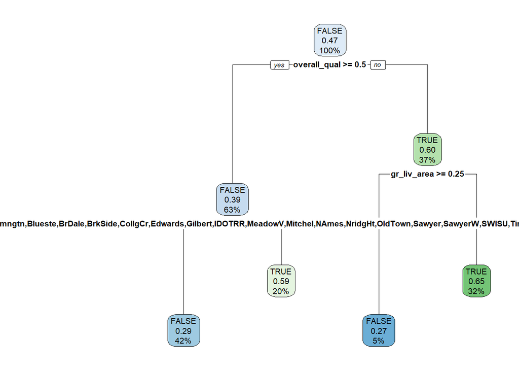

```r
pacman::p_load(tidymodels,
               rpart.plot)

# Chunk takes ~5 minutes to execute

default_cv = train %>% vfold_cv(v =5)
default_tree = decision_tree(mode ="classification",
                             cost_complexity = tune(),
                             tree_depth = tune()) %>%
               set_engine("rpart")

# Defining recipe
default_recipe = recipe(undervalued ~., data = train)
# Defining workflow
default_flow = workflow() %>%
  add_model(default_tree) %>%
  add_recipe(default_recipe)
# Tuning
default_cv_fit = default_flow %>%
  tune_grid(
    default_cv,
    grid = expand_grid(
      cost_complexity = seq(0, 0.15, by = 0.01),
      tree_depth = c(1,2,5,10),
    ),
    metrics = metric_set(accuracy, roc_auc))
# Fitting and selecting best model
best_flow = default_flow %>%
  finalize_workflow(select_best(default_cv_fit, metric = "accuracy")) %>%
  fit(data = train)
best_tree = best_flow %>% extract_fit_parsnip()
best_tree$fit %>% rpart.plot::rpart.plot(roundint=F)
```

```r
# Summary statistics and plotting
printcp(best_tree$fit)
```

```
##
## Classification tree:
## rpart::rpart(formula = ..y ~ ., data = data, cp = ~0, maxdepth = ~2)
##
## Variables actually used in tree construction:
## [1] gr_liv_area  neighborhood overall_qual
##
## Root node error: 549/1168 = 0.47003
##
## n= 1168
##
##         CP nsplit rel error  xerror     xstd
## 1 0.165756      0   1.00000 1.00000 0.031070
## 2 0.078324      1   0.83424 0.90346 0.030770
## 3 0.047359      2   0.75592 0.86885 0.030599
## 4 0.000000      3   0.70856 0.82332 0.030320
```

```r
best_tree$fit$variable.importance
```

```
##    neighborhood    overall_qual     gr_liv_area      year_built       bsmt_qual
##       38.579931       25.102234       24.271346        9.810069        9.636950
##     garage_cars tot_rms_abv_grd       ms_zoning     x2nd_flr_sf     x1st_flr_sf
##        9.579243        6.247153        6.040665        5.726557        5.205961
##  bedroom_abv_gr   total_bsmt_sf     exterior2nd     exterior1st      land_slope
##        2.863278        2.082384        1.895110        1.776666        1.421333
##           alley
##        1.184444
```

```r
# Predicting values
as.data.frame(predict(best_tree, new_data=train)) -> df1
```

Looking at our first decision tree, there are several things worth considering:

- The `neighborhood` variables was ranked as the greatest variable of importance.
  - This might be good to know if we use this model on future data on housing from the same selection of neighborhoods, but wouldn’t perform well on data from other areas where the distinction between neighborhood is less explanatory
- The significant variables are different than those suggested and used in our previous model

For the next trees, we will omit the `neighborhood` variable in an effort to produce a model that is more generalizable. While we could likely develop a way to preserve the information that this variable contributes to the data (like by creating an additional variable(s) with metrics pertaining to the given neighborhood such as crime-rate, median income, average education, neighborhood demographics, etc.), it could provide insight if create a model that cannot look to the neighborhood of an observation.

```r
set.seed(123)
train_hold = clean_house %>%
   select(-c("neighborhood")) %>%
   mutate(undervalued = as.factor(undervalued)) %>%
   sample_frac(0.8)
test_hold = anti_join(clean_house, train_hold, by = 'id')

train_hold %<>% select(-c("id"))
test_hold %<>% select(-c("id"))
```

And now to plant another tree

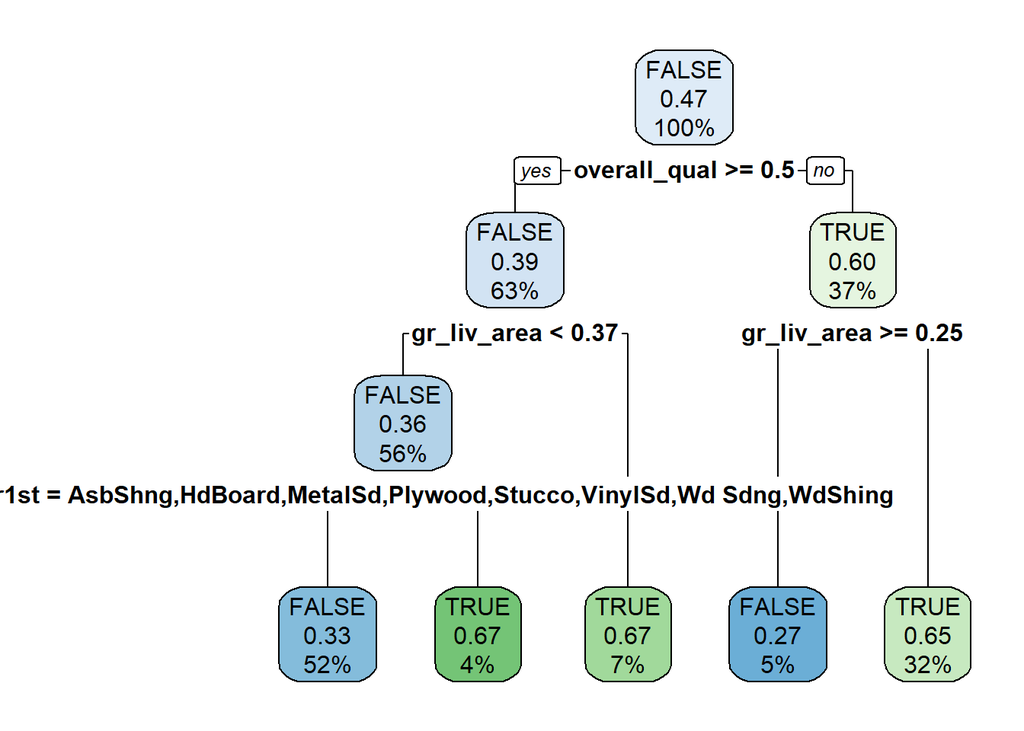

```r
default_recipe = recipe(undervalued ~., data = train_hold)
default_flow = workflow() %>%
  add_model(default_tree) %>%
  add_recipe(default_recipe)
default_cv_fit = default_flow %>%
  tune_grid(
    default_cv,
    grid = expand_grid(
      cost_complexity = seq(0, 0.15, by = 0.01),
      tree_depth = c(1,2,5,10),),
    metrics = metric_set(accuracy, roc_auc))
best_flow = default_flow %>%
  finalize_workflow(select_best(default_cv_fit, metric = "accuracy")) %>%
  fit(data = train_hold)
best_tree2 = best_flow %>% extract_fit_parsnip()
best_tree2$fit %>% rpart.plot::rpart.plot(roundint=F)
```

```r
# Summary and plotting
printcp(best_tree2$fit)
```

```
##
## Classification tree:
## rpart::rpart(formula = ..y ~ ., data = data, cp = ~0.02, maxdepth = ~5)
##
## Variables actually used in tree construction:
## [1] exterior1st  gr_liv_area  overall_qual
##
## Root node error: 549/1168 = 0.47003
##
## n= 1168
##
##         CP nsplit rel error  xerror     xstd
## 1 0.165756      0   1.00000 1.00000 0.031070
## 2 0.049180      1   0.83424 0.83424 0.030393
## 3 0.047359      2   0.78506 0.85428 0.030516
## 4 0.029144      3   0.73770 0.81421 0.030257
## 5 0.020000      4   0.70856 0.79417 0.030110
```

```r
best_tree2$fit$variable.importance
```

```
##     gr_liv_area    overall_qual     x2nd_flr_sf tot_rms_abv_grd       full_bath
##      38.1941946      25.5376667      12.4301505      11.4037635      11.2919544
##     exterior1st      year_built       bsmt_qual     garage_cars     exterior2nd
##      10.0149479       9.8100685       9.6369497       9.5792434       6.9669203
##     x1st_flr_sf   total_bsmt_sf  bedroom_abv_gr      condition2      functional
##       6.9248310       3.6293675       2.8632784       0.2177163       0.2177163
##       sale_type
##       0.2177163
```

```r
# Predicting values
as.data.frame(predict(best_tree2, new_data=train_hold)) -> df2
```

From this seemingly small change, we can gather some additional insight into the story that is hiding in our data. Obviously the `neighboorhood` variable must hold some importance since its commission changes the resulting tree, but I believe there is additional information that the `neighboorhood` could carry.

While the name of a neighborhood is nothing more than a logical arrangement of letters and spaces, geographic boundaries could imply several characteristics that would apply to a home being sold within those boundaries. Even if the floor-plan and characteristics of two given homes are 100% similar apart from the neighborhood, there could still be differences that affect sale prices

- *Crime rates*
  - A quick online search could determine reports of crimes for a given geographic area, knowledge of which could affect the price one is willing to pay for a home if house is located in crime-heavy area
- *Public education jurisdiction*
  - Results in distinct differences determined by specific boundaries. Even the side of the street a home is on could determine if their children attend an A-rated school versus a D-rated school
- *Community*
  - Not as black-and-white as education or crime, but could potentially provide some explanatory effect
  - Examples: Willingness to pay more than would otherwise in order to live close to family, friends, cultural significance (e.g. Spanish-speaking), class-status/“prestige”, etc
  - Aforementioned examples could potentially result in consumer willingness to pay a price either higher or lower than they would otherwise accept
- *Presences of Homeowners Association*
  - Because who the hell wants to be told what color they are allowed to paint their house, or if they are able to have a garden on their property that is visible from the street, or how long their grass is “allowed” to grow? This is America! - (unless we are looking at data from another country)

Before moving on to another model, let’s first consider the predictions from the previous trees.

```r
df1 %<>% rename(pred_tree = names(.)[1])
# Creating confusion matrix
table(Actual = train$undervalued,
      Predicted = df1$pred_tree)
```

```
##        Predicted
## Actual  FALSE TRUE
##   FALSE   390  229
##   TRUE    160  389
```

```r
TN = 390
TP = 389
FP = 229
FN = 160
Sensitivity = TP/(TP + FN)
# (Number of true positive assessment)/(Number of
#  all positive assessment)
Specificity = TN/(TN + FP)
# (Number of true negative assessment)/(Number of
#  all negative assessment)
Accuracy   = (TN + TP)/(TN+TP+FN+FP)
# (Number of correct assessments)/Number of
#  all assessments)
metrics_tree1 = rbind(Sensitivity,Specificity,Accuracy)
metrics_tree1
```

```
##                  [,1]
## Sensitivity 0.7085610
## Specificity 0.6300485
## Accuracy    0.6669521
```

```r
df2 %<>% rename(pred_tree = names(.)[1])
table(Actual = train_hold$undervalued,
      Predicted = df2$pred_tree)
```

```
##        Predicted
## Actual  FALSE TRUE
##   FALSE   446  173
##   TRUE    216  333
```

```r
TN = 446
TP = 333
FP = 173
FN = 216
Sensitivity = TP/(TP + FN)
# (Number of true positive assessment)/(Number of
#  all positive assessment)
Specificity = TN/(TN + FP)
# (Number of true negative assessment)/(Number of
#  all negative assessment)
Accuracy   = (TN + TP)/(TN+TP+FN+FP)
# (Number of correct assessments)/Number of
#  all assessments)
metrics_tree2 = rbind(Sensitivity,Specificity,Accuracy)
metrics_tree2
```

```
##                  [,1]
## Sensitivity 0.6065574
## Specificity 0.7205170
## Accuracy    0.6669521
```

Looks like we were able to produce more stable models with decent accuracy (on the training set at least, we will have to see how it performs on testing). If the single decision trees produced these different results, let’s see how an ensemble of trees (i.e. random forest) will perform

### Random Forest

I saw the values of the training/testing sets when `unique(test$neighborhood)` were both the same, so I figured that it would be good practice to keep the `neighborhood` variable for the random forest modeling. If there was an uneven distribution of neighborhoods in both sets, then we would need to consider a different resampling method or removing the variable.

```r
# Refreshing our training and testing sets
set.seed(123)
train = clean_house %>% mutate(undervalued = as.factor(undervalued)) %>%
   sample_frac(0.8)
test  = anti_join(clean_house, train, by = 'id')
train %<>% select(-c("id"))
test %<>% select(-c("id"))

library(randomForest)
mod_rf = randomForest(formula = undervalued ~ .,
                      data = train,
                      importance = T,
                      ntree = 100)
importance(mod_rf)
```

```
##                       FALSE        TRUE MeanDecreaseAccuracy MeanDecreaseGini
## ms_sub_class     2.37110510 -0.59289756          2.230481757       6.25671639
## ms_zoning        2.96050446 -0.39285711          2.660849202       2.98502094
## lot_frontage     1.31352137 -0.75593306          0.525960886      14.47293022
## lot_area         0.14130204  2.97691136          2.481027539      21.74603953
## street           0.00000000  1.00503782          1.005037815       0.14684310
## alley            2.08679934 -0.93761809          1.052651776       1.55984791
## lot_shape        0.53106960 -0.86906473         -0.280213261       4.27020668
## land_contour     1.39066020  0.96429231          1.761896764       3.48457769
## utilities        0.00000000  0.00000000          0.000000000       0.01714286
## lot_config       0.84471029  1.31603075          1.538559412       5.68282684
## land_slope       0.47421537  1.33882923          1.771745823       1.46127417
## neighborhood     9.15263439 -1.41384978          7.012149979      49.00285106
## condition1       1.52000381  0.91315354          1.974712262       6.14739613
## condition2       0.00000000 -1.00503782         -1.005037815       0.19665702
## bldg_type        1.12996782  0.12753681          0.942682077       3.37526159
## house_style      1.38336800  0.66013400          1.800959183       5.70180504
## overall_qual     1.68452586  6.57037197          6.717004190      16.11463389
## overall_cond     2.11388375 -0.11103405          1.758216763       6.25304209
## year_built       3.16800540  0.88441877          3.404948037      14.99962580
## year_remod_add   2.88187116  1.79992658          4.174840176      14.38416237
## roof_style       1.49534911 -1.44243954         -0.011418427       3.19500972
## roof_matl       -0.01075588  0.33854578          0.254120308       0.59345575
## exterior1st      4.30936617 -1.75965058          2.426072343      17.01934930
## exterior2nd      4.91475920 -1.17302712          2.957139085      18.57794048
## mas_vnr_type     1.29290657 -0.07143388          0.953393308       3.65983121
## mas_vnr_area     2.40413643 -1.79750713          0.688785035      11.17923784
## exter_qual       3.28861788  2.58876793          4.100838893       4.85561014
## exter_cond       3.03014026 -0.62215309          2.054099581       2.12103282
## foundation       1.80653485  2.53050396          3.088919431       4.08226693
## bsmt_qual        0.21747787  1.18317604          1.048360612       3.49740634
## bsmt_cond        1.34455606  0.58695672          1.156748477       1.93102645
## bsmt_exposure    0.39992031  3.24006287          2.459550251       8.83336503
## bsmt_fin_type1  -0.75334871  1.62290860          0.644859625      11.48029368
## bsmt_fin_sf1     0.25873156  3.55411626          2.947305142      16.96627929
## bsmt_fin_type2   1.96117137 -0.71964105          1.023802693       5.58847525
## bsmt_fin_sf2     2.45084614 -0.68022909          1.576533782       3.83102914
## bsmt_unf_sf      2.45604685  1.09652020          3.087944915      18.86575270
## total_bsmt_sf    2.91840785  1.87437567          3.844247593      19.86606691
## heating         -0.85114868 -0.46607137         -1.289622553       0.41671989
```

[output cut: 25 more lines]

```
## paved_drive      1.01075020 -2.26737841         -1.005071285       1.35452269
## wood_deck_sf     1.57367433  0.33060731          1.733572642      11.20831386
## open_porch_sf    0.70978466  1.53498262          1.850285953      14.98678612
## enclosed_porch  -2.33560242  0.35132891         -1.775893268       3.88019036
## x3ssn_porch      0.05564202 -1.01153916         -0.599054567       1.26608555
## screen_porch     0.55810559  0.05994389          0.480398720       4.11634414
## pool_area        0.00000000 -1.00503782         -1.005037815       0.09971477
## pool_qc          0.00000000  0.03414999          0.031273130       0.10317498
## fence            2.17475352  0.02116753          1.877720232       4.87639051
## misc_feature     1.36030512 -1.48585604         -0.136666022       1.17537986
## misc_val         1.90386644 -0.17248438          1.208188046       1.93359543
## mo_sold          1.49376084  0.49456602          1.248362677      13.38199354
## yr_sold         -2.26464306 -0.93846176         -2.191942636       8.68738217
## sale_type       -0.91609319 -0.18198627         -0.890808478       2.18995595
## sale_condition   0.89141467  0.57870719          1.058412573       5.50860524
```

```r
train$pred_rf = predict(mod_rf, type="response", newdata = train)
# Creating confusion matrix
table(Actual = train$undervalued,
      Predicted = train$pred_rf)
```

```
##        Predicted
## Actual  FALSE TRUE
##   FALSE   619    0
##   TRUE      0  549
```

Looks like the neighborhood ended up being a significant variable according to the random forest model. Good thing we kept it!